# Data Visulization (Incarceration)

James Doan

## Introduction and Summary Statistics

Justice is currently a prominent value to uphold. In order to deconstruct racism, we must understand how different systems are currently affecting BIPOC populations. Here, within this conducted research, we debunk different statistics that pertain to our US justice system. Within this assignment, I wanted to grasp a better understanding of different statistics of different jailed populations from different people of color.

latinx_jail_pop: Finds the jailed population of Latinx folks  
aapi_jail_pop: Finds the jailed population of AAPI folks  
white_jail_pop: Finds the jailed population of White folks  
female_adult_jail_pop: Finds the jailed population of female adults  
female_pop_15to64: Finds the jailed population of females from ages 15 to 64

Within the research, we were able to find more demographics and convey what these statistics mean.

- What is the change of the proportion of jailed population of Latinx folks to the total population of folks between 1990 and 2018?  
  *Answer:* 0.4246538
- What is the change of the proportion of jailed population of AAPI folks to the total population of folks between 1990 and 2018?  
  *Answer:* 1.3518307
- What is the change of the proportion of jailed population of White folks to the total population of folks between 1990 and 2018?  
  *Answer:* 0.5884219
- Which county in New York State had the most total population of jailed females?  
  *Answer:* New York County
- Which county in Washington state had the most total population between 15-64 year old Females?  
  *Answer:* King County

## Time Trend Chart: Chart the trend of jailed population of latinx folk vs. the total population of jailed folk within the years of 2000 to 2018

While diving deeper in the lens of Latinx folks, we wanted to be able to compare the total jailed population to get more insight of the comparison of Latinx folks to the Total Jailed population

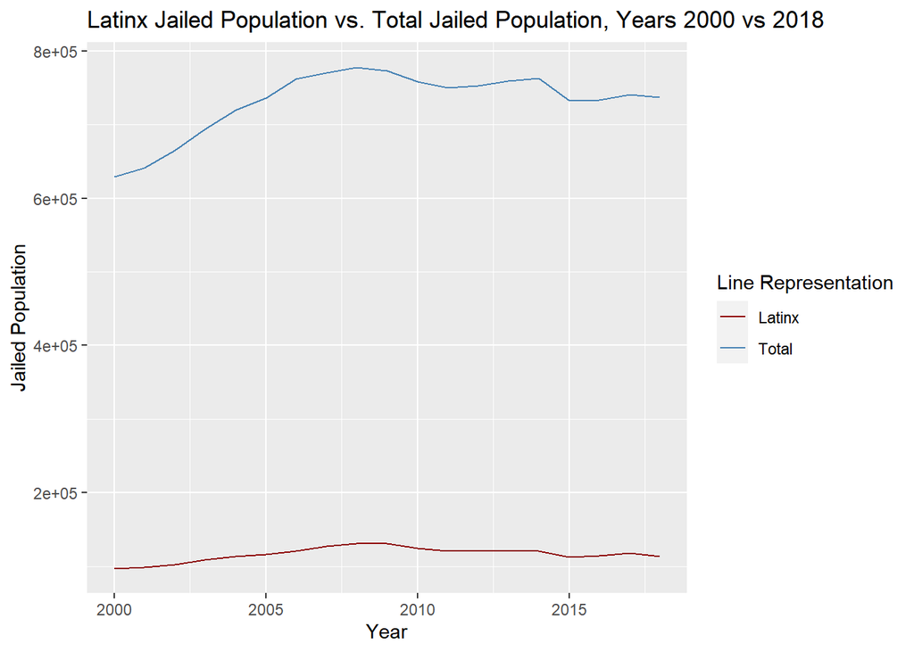

Overtime, it showed that within this chart comparing the total amount of people who were jailed to that of the population of Latinx folks, there was a significant difference. Within the graph you can see that the total amount is roughly 6 times as much as to Latinx folks. Here it depicted a large growth and a similar declination over the more recent years, but it followed the main trend of the total jailed population.

## Variable Comparison Chart: Compare the total of the total aapi jailed populations at each county vs. white jailed populations

Here, I wanted to learn about folks who have similar backgrounds to me. As an Asian American, I wanted to compare the statistics of AAPI folks who are jailed to our white counterparts.

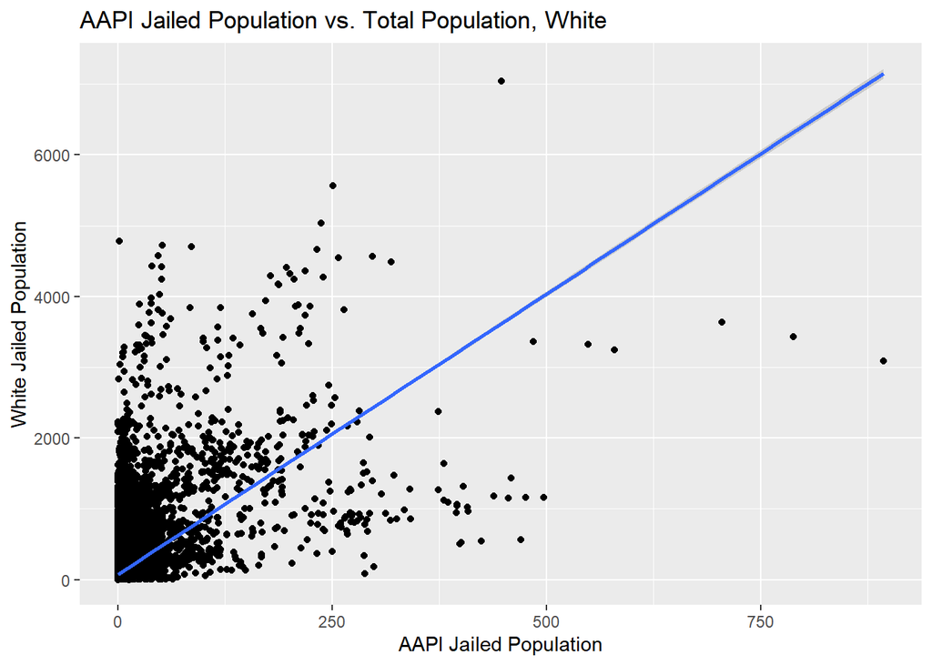

## Mapping: Mapping: Map the Black total Jail Population within the year 2017 and Map the Total Male Jail Population within the year 2017

Lastly, I wanted to portray another important statistic that may not be understandable through just seeing logistical numbers. Here, I wanted to include two maps to illustrate some injustices when it comes to seeing our US justice system.

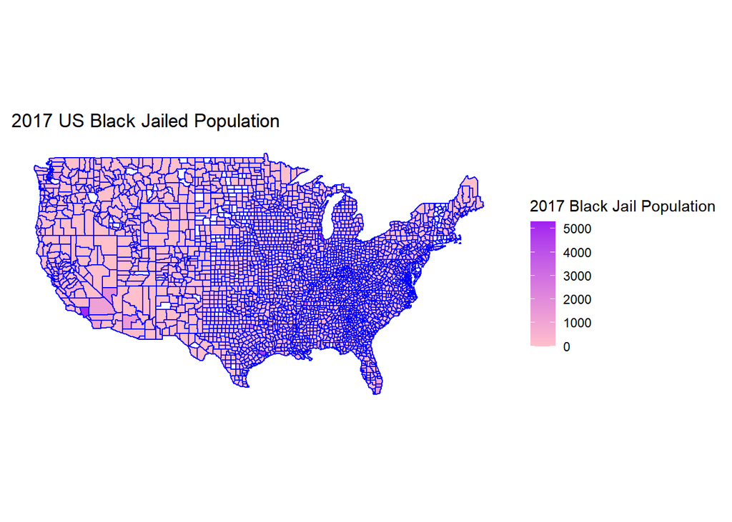

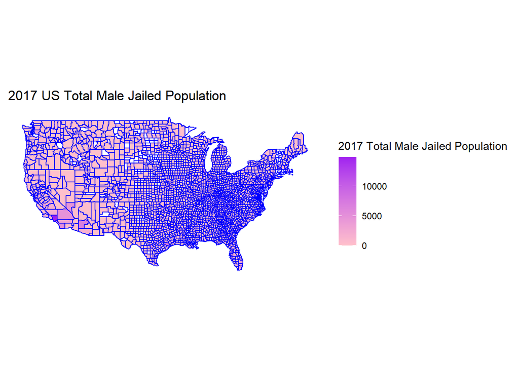